# Participation and Budget 2018 (article repo)

**Carla de Paiva Bezerra** (carla.bezerra@gmail.com)  
**Murilo Junqueira** (m.junqueira@yahoo.com.br)

## 1. Short Description

This is the repo for the working paper “Why has the Participatory Budgeting declined in Brazil?”.

In this repo are all codes, data, metadata and instructions for full replication of the research.

For full paper: carlabezerra.info -> Research

### 1.1 Paper Abstract

Participatory Budgeting (PB) is a policy innovation that originated in Brazil and is recognized worldwide by scholars and international organizations as an effective policy tool for directly involving the population in decisions about the local budget. Its diffusion in Brazil was strongly stimulated by the Workers’ Party (Partido dos Trabalhadores, PT), as a showcase of the “Petista Way of Governing”. However, when the Party took the Federal Office, it abandoned PB as its main participatory policy priority. The motivation for such drastic change in policy preference remains unexplained, by both scholars and the Party itself. To understand the reasons for it, we present an original hypothesis, based on party adaptation to increasing fiscal and budgetary rigidity. To test this hypothesis, we use a mixed-methods approach, with qualitative data, such as interviews and newspapers content analysis, and quantitative panel-data analysis: the correlation between the state of public finances and the local PB adoption probability. Our results show that the most significant factors for explaining PB adoption by a municipality are: having the PT as incumbent, a bigger population and a higher budget per capita. The factors that stood out to explain PB continuity are: political-administrative continuity and a higher investment rate.

## 2. How to replicate the research

There are three ways to replicate this research, depending on how deep the replicantion is.

- For a **soft replication**, it is possible to just download the file “data/analysisdata/DataAnalysis.csv” and replicate the regression models, figures and tables of the paper using “src/Models.R” file and its connected functions.
- For a **medium replication**, the reviewer could check the variables of final dataset running the code “src/AnalysisDataOutput.R” and all data in “data/dataset” folder.
- For a **full replication**, the reviewer could recreate the dataset from original data sources using “src/DatabaseOutput.R” file. In this case, it is very important a careful reading in the data section below, especially in this important warning.

## 3. Code

### 3.1 Code description

The main scripts of this project are

1. src/DatabaseOutput.R
2. src/AnalysisDataOutput.R
3. src/Models.R

The first one create the relational database available in “data/dataset” that clean and connect all raw data. The second script create file “data/analysisdata/DataAnalysis.csv”, from which the regression models, figures and tables of the paper where generated. The last script yields the regression models, figures and tables of the paper.

These three scripts use many functions available in the folders “src/generalFunctions” and “src/specifcFuntions” (see Scripts folder section). The complete dependence network of the codes and data files are avalible in “data/dataset/FileTracing.csv”

### 3.2 Software Dependencies

1. R version 3.4.3 (2017-11-30) – “Kite-Eating Tree”
2. Java
3. Microsoft Access Database Engine (for windows, [download here](https://www.microsoft.com/en-us/download/details.aspx?id=54920))

The R packages needed to run the codes are described in the scripts.

## 4. Data

Our workflow in this research is first transform the raw data in a relational dataset that clean and connect all raw data (avalible in “data/dataset”) and then use this relational dataset to create the variables used in regression models, tables and figures (file "data/analysisdata/DataAnalysis.csv). Almost all steps of data collection, cleaning and filtering, as well as variable creation, are in R codes. Basicaly, it is only necessary point and click to download data from sources that don’t allow direct download or use captcha. There are other few cases of point and click, basically to unzip or extract data from accdb files. All this cases are indicated in R code comments.

We recommend a careful review of the following files, that describe the dataset and variable generation process:

- **data/dataset/Codebook.csv:** Description of all variables present in data and metadata files.
- **data/dataset/RawFilesList.csv:** List of raw data files. From this list came almost all the information used in this project, incluing data from our own research. The only data that are not in this list are data that came from IPEA and CEPESP APIs. This file contains the URL link to original data source.
- **data/dataset/FileTracing.csv:** Shows the relationship between the files of this project. Shows which files were used to generate other files, including programming codes, functions and data sources.

Warning: Many databases files of this research are too large to be uploaded to github, so we omit some data files from this repository. Therefore, to a full replication, it is necessary go to original source, download the data and then run the script “src/DatabaseOutput.R” to rebuild the dataset. The file “data/dataset/RawFilesList.csv” shows the URL links of the original source data and the correct folder to put the files in order to make the R codes work.

### 4.1. Data sources

Below are the summary of the data sources. For a more detailed view of the data sources see “data/dataset/RawFilesList.csv”.

1. **Spada, P. 2012**. “Brazilian Participatory Budgeting Census: 1989-2012.” Available at: http://participedia.net/en/content/brazilian-participatory-budgeting-census / Access date: April 20, 2018. (licensed under CC BY-NC-SA 3.0).
2. **IPEADATA:** A portal of the Brazilian Government Institute for Applied Economics Research, that puts together several data sources of the Brazilian Governement (http://www.ipeadata.gov.br). The data was downloaded by IPEA API through ipeadatar R package.
3. **CEPESP:** Center for Politics and Economics of the Public Sector (CEPESP) of the Getulio Vargas Foundation (FGV) provides access to Brazilian electoral data through a user friendly platform called CepespData website (http://cepespdata.io/). We use its R package, called cepespR (https://github.com/Cepesp-Fgv/cepesp-r).
4. **TSE:** Organized and documented access to the Brazilian Electoral Superior Court (TSE) data on elections in Brazil from 1998 to 2016.
5. **FINBRA**: Offical Accounting Data for Brazilian Municipalities (1989-2016), gathered by National Treasury Secretary of the Ministry of Economy
6. **Own research**: In many cases we had to create data, mainly to be able to connect data from different sources. All data that was created by ourselves are discriminated in “data/dataset/RawFilesList.csv”.

### 4.2. ER diagram

Entity-relationship diagram of “data/dataset” folder.

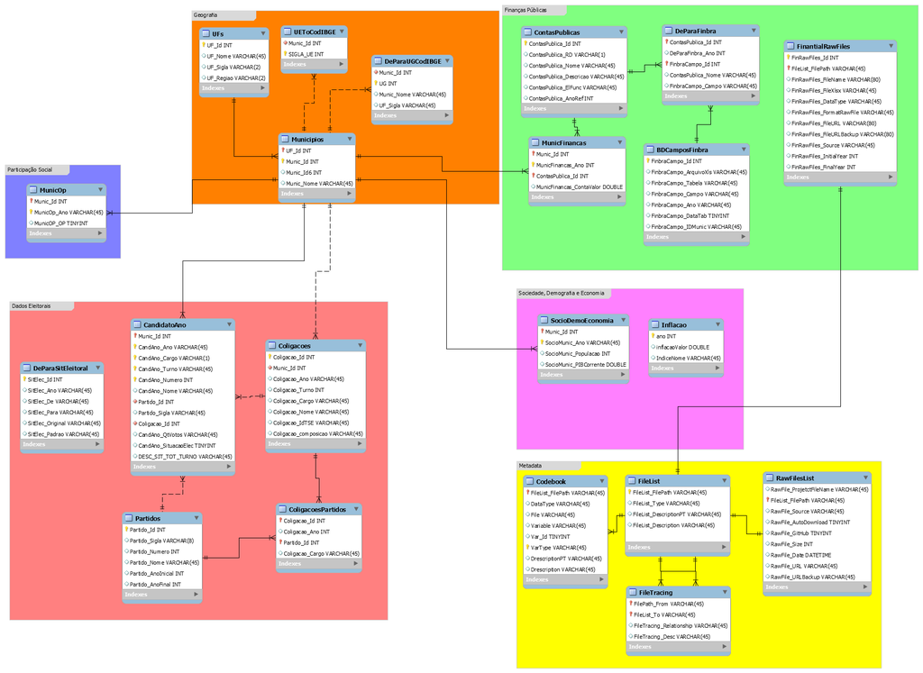

Entity-relationship diagram

Original MYSQL Workbench file in “data/metadata/dataModel_MySQL/”.

### 4.3. Final Dataset

Final dataset, “data/analysisdata/DataAnalysis.csv”, derived from all raw data above. It includes muncipality-year values for all Brazilian municipalities that had above 50.0000 inhabintants in 1996. The variables are detailes in the “data/dataset/Codebook.csv”.

## 5. Folders and Files

### 5.1. Folders descriptions

The main folders are:

- **data**
- **doc**
- **src**

Inside the “data” folder (and its subfolders) are both raw data and clean and transformed data. There is also all the metadata used in this project. In the “doc” folder are the paper itself, as well as figures, tables and presentations. Within the “src” folder are all the codes and code functions used in the project.

#### 5.1.1 Data folder description

The complete structure of the “data” folder is the following:

- data
  - analysisdata
  - dataset
  - metadata
    - dataModel_MySQL
      - History
    - documentation
  - raw
    - CepespData
      - .cepespdata
    - Finbra
      - ExcelFiles
      - OriginalFiles
    - PBCENSUS Spada
    - TSE
      - 2000
      - TSE-relacao-candidatos-1996
  - temp

Folders description:

- **data/analysisdata:** This folder contains the final dataset, which is a data report containing a mixt of modeled data and indicators (transformed data) used to run the project’s statistical models, tables and figures.
- **data/dataset:** Data extracted from the raw sources into a tidy relational base model. All data used to create final dataset variables are extracted from the files in this folder. This folder also have most of metadata that computacional scripts uses to create the database. All data are in csv format.
- **data/metadata:** Gathers part of the documentation about the data. The metadata that are in dataset format are in “data/dataset” folder. This folder contains metadata that are in other formats, like MySQL Workbench files or text files.
- **data/metadata/dataModel_MySQL:** MySQL Workbench files that show the entity-relationship diagram of the dataset in “data/dataset” folder. It contais a “History” folder that shows the evolution of the data model in this project.
- **data/metadata/documentation:** Codebook and other documentation about dataset variables.
- **data/raw:** Stores most of the downloaded raw data, like TSE, STN-Finbra and PBCENSUS data. Data that came from CEPESP API, IPEA API or is result of our own research was inserted directly in “data/dataset”. There is also a directory for storing cache data of CEPESP API (ommited in github), to avoid redundant downloads. Mode detail about raw data in Data sources section
- **data/temp:** Directory for temporary data storage

#### 5.1.2 Documments folder description

The complete structure of the “doc” folder is the following:

- doc
  - figures
  - paper
  - presentations
  - tables

The content of each folder is pretty self-explanatory, containing figures, text of the paper, authors presentations and tables of the paper.

#### 5.1.2 Scripts folder description

The complete structure of the “src” folder is the following:

- src
  - generalFunctions
  - specifcFuntions

Folders description:

- **src/:** Gathers all the programming codes (only R language was used). In this folder are the scripts that call the other functions.
- **src/generalFunctions:** Here are very general functions that probably will be used by the authors in other projects.
- **src/specifcFuntions:** Here are functions for the specif extraction of the data used in this project. Mode detail about codes mechanics in Code description section

### 5.2. Files Description and File Dependence

The description of the role of each files in this project are in “data/dataset/FileList.csv”. We also recommend a careful review of metadata files “data/dataset/FileTracing.csv”, that describes the interdependence between codes and data files and the “data/dataset/Codebook.csv” that describes all variables present in data and metadata files.